# Logistic regression

The theme of the third week was logistic regression.

As a prelude for this week main theme there were some data pretreatment. More about that can be seen from other file. Main idea in the pretreatment was that we merged two data sets and calculated two more variables.

## Preparation and overview

The data that is used is from two separate surveys. The theme is the student alcohol consumption. There is 35 variables from the survey and one for the running number. We have 382 observations. Below can be seen functions for to observate the variables and data set.

```r
head(alcodata)
```

```
##   X school sex age address famsize Pstatus Medu Fedu     Mjob     Fjob
## 1 1     GP   F  18       U     GT3       A    4    4  at_home  teacher
## 2 2     GP   F  17       U     GT3       T    1    1  at_home    other
## 3 3     GP   F  15       U     LE3       T    1    1  at_home    other
## 4 4     GP   F  15       U     GT3       T    4    2   health services
## 5 5     GP   F  16       U     GT3       T    3    3    other    other
## 6 6     GP   M  16       U     LE3       T    4    3 services    other
##       reason nursery internet guardian traveltime studytime failures
## 1     course     yes       no   mother          2         2        0
## 2     course      no      yes   father          1         2        0
## 3      other     yes      yes   mother          1         2        2
## 4       home     yes      yes   mother          1         3        0
## 5       home     yes       no   father          1         2        0
## 6 reputation     yes      yes   mother          1         2        0
##   schoolsup famsup paid activities higher romantic famrel freetime goout
## 1       yes     no   no         no    yes       no      4        3     4
## 2        no    yes   no         no    yes       no      5        3     3
## 3       yes     no  yes         no    yes       no      4        3     2
## 4        no    yes  yes        yes    yes      yes      3        2     2
## 5        no    yes  yes         no    yes       no      4        3     2
## 6        no    yes  yes        yes    yes       no      5        4     2
##   Dalc Walc health absences G1 G2 G3 alc_use high_use
## 1    1    1      3        5  2  8  8     1.0    FALSE
## 2    1    1      3        3  7  8  8     1.0    FALSE
## 3    2    3      3        8 10 10 11     2.5     TRUE
## 4    1    1      5        1 14 14 14     1.0    FALSE
## 5    1    2      5        2  8 12 12     1.5    FALSE
## 6    1    2      5        8 14 14 14     1.5    FALSE
```

```r
str(alcodata)
```

```
## 'data.frame':    382 obs. of  36 variables:
##  $ X         : int  1 2 3 4 5 6 7 8 9 10 ...
##  $ school    : Factor w/ 2 levels "GP","MS": 1 1 1 1 1 1 1 1 1 1 ...
##  $ sex       : Factor w/ 2 levels "F","M": 1 1 1 1 1 2 2 1 2 2 ...
##  $ age       : int  18 17 15 15 16 16 16 17 15 15 ...
##  $ address   : Factor w/ 2 levels "R","U": 2 2 2 2 2 2 2 2 2 2 ...
##  $ famsize   : Factor w/ 2 levels "GT3","LE3": 1 1 2 1 1 2 2 1 2 1 ...
##  $ Pstatus   : Factor w/ 2 levels "A","T": 1 2 2 2 2 2 2 1 1 2 ...
##  $ Medu      : int  4 1 1 4 3 4 2 4 3 3 ...
##  $ Fedu      : int  4 1 1 2 3 3 2 4 2 4 ...
##  $ Mjob      : Factor w/ 5 levels "at_home","health",..: 1 1 1 2 3 4 3 3 4 3 ...
##  $ Fjob      : Factor w/ 5 levels "at_home","health",..: 5 3 3 4 3 3 3 5 3 3 ...
##  $ reason    : Factor w/ 4 levels "course","home",..: 1 1 3 2 2 4 2 2 2 2 ...
##  $ nursery   : Factor w/ 2 levels "no","yes": 2 1 2 2 2 2 2 2 2 2 ...
##  $ internet  : Factor w/ 2 levels "no","yes": 1 2 2 2 1 2 2 1 2 2 ...
```

[output cut: 22 more lines]

```r
summary(alcodata)
```

```
##        X          school   sex          age        address famsize
##  Min.   :  1.00   GP:342   F:198   Min.   :15.00   R: 81   GT3:278
##  1st Qu.: 96.25   MS: 40   M:184   1st Qu.:16.00   U:301   LE3:104
##  Median :191.50                    Median :17.00
##  Mean   :191.50                    Mean   :16.59
##  3rd Qu.:286.75                    3rd Qu.:17.00
##  Max.   :382.00                    Max.   :22.00
##  Pstatus      Medu            Fedu             Mjob           Fjob
##  A: 38   Min.   :0.000   Min.   :0.000   at_home : 53   at_home : 16
##  T:344   1st Qu.:2.000   1st Qu.:2.000   health  : 33   health  : 17
##          Median :3.000   Median :3.000   other   :138   other   :211
##          Mean   :2.806   Mean   :2.565   services: 96   services:107
##          3rd Qu.:4.000   3rd Qu.:4.000   teacher : 62   teacher : 31
##          Max.   :4.000   Max.   :4.000
##         reason    nursery   internet    guardian     traveltime
##  course    :140   no : 72   no : 58   father: 91   Min.   :1.000
##  home      :110   yes:310   yes:324   mother:275   1st Qu.:1.000
##  other     : 34                       other : 16   Median :1.000
##  reputation: 98                                    Mean   :1.448
##                                                    3rd Qu.:2.000
##                                                    Max.   :4.000
##    studytime        failures      schoolsup famsup     paid     activities
##  Min.   :1.000   Min.   :0.0000   no :331   no :144   no :205   no :181
##  1st Qu.:1.000   1st Qu.:0.0000   yes: 51   yes:238   yes:177   yes:201
##  Median :2.000   Median :0.0000
##  Mean   :2.037   Mean   :0.2016
##  3rd Qu.:2.000   3rd Qu.:0.0000
##  Max.   :4.000   Max.   :3.0000
##  higher    romantic      famrel         freetime        goout
##  no : 18   no :261   Min.   :1.000   Min.   :1.00   Min.   :1.000
##  yes:364   yes:121   1st Qu.:4.000   1st Qu.:3.00   1st Qu.:2.000
##                      Median :4.000   Median :3.00   Median :3.000
##                      Mean   :3.937   Mean   :3.22   Mean   :3.113
##                      3rd Qu.:5.000   3rd Qu.:4.00   3rd Qu.:4.000
##                      Max.   :5.000   Max.   :5.00   Max.   :5.000
##       Dalc            Walc           health         absences
##  Min.   :1.000   Min.   :1.000   Min.   :1.000   Min.   : 0.0
##  1st Qu.:1.000   1st Qu.:1.000   1st Qu.:3.000   1st Qu.: 1.0
##  Median :1.000   Median :2.000   Median :4.000   Median : 3.0
##  Mean   :1.482   Mean   :2.296   Mean   :3.573   Mean   : 4.5
##  3rd Qu.:2.000   3rd Qu.:3.000   3rd Qu.:5.000   3rd Qu.: 6.0
##  Max.   :5.000   Max.   :5.000   Max.   :5.000   Max.   :45.0
##        G1              G2              G3           alc_use
##  Min.   : 2.00   Min.   : 4.00   Min.   : 0.00   Min.   :1.000
##  1st Qu.:10.00   1st Qu.:10.00   1st Qu.:10.00   1st Qu.:1.000
##  Median :12.00   Median :12.00   Median :12.00   Median :1.500
##  Mean   :11.49   Mean   :11.47   Mean   :11.46   Mean   :1.889
##  3rd Qu.:14.00   3rd Qu.:14.00   3rd Qu.:14.00   3rd Qu.:2.500
##  Max.   :18.00   Max.   :18.00   Max.   :18.00   Max.   :5.000
##   high_use
##  Mode :logical
##  FALSE:268
##  TRUE :114
##  NA's :0
##
##
```

## Logistic regression model and analysis

### Relationships between chosen variables

Next task was to observe relationships between alcohol consumption and other four variables. I chose sex (*sex*), age (*age*), mother’s education (*Medu*) and extra-curricular activities (*activities*). Variables *sex* and *activities* are already binary. Variable *age* has 7 different values from 15 to 22. To make regression model easier to interpret I recoded variable *age* to the variable *ageGroup* with two groups: age under 18 and age at least 18. Also variable *Medu* had five values. I merged options from 0 to 2 and 3 to 4. I named them “low education” and “high education”

```r
#Creating two new variables from original variables age and Medu. I used if else syntax.
alcodata$ageGroup <- ifelse(alcodata$age < 18,
c("15-17"), c("18-22"))

alcodata$MeduGroup <- ifelse(alcodata$Medu > 2,
c("high education"), c ("low education"))
```

As a hypothesis I state that there is no differences between females of males. This might easily be false, but I am not familiar with portuguese culture. I think older people will use more alcohol. I also think that mother’s education have some effect, I believe that if mother has low education level then her child is more likely high consumer of alcohol. I think that extra-curricular activities doesn’t affect to alcohol the consumption.

To see if there is relationship between two categorial variables I used chi-squared test as a statistical test. The main idea of chi-squared test is to test null hypothesis that is there is no differences between the groups. If the p-value of the test is less than 0,05 (or 0,01) null hypothesis can be rejected. More about this test can be read from [Wikipedia](https://en.wikipedia.org/wiki/Pearson%27s_chi-squared_test).

I will use function CrossTable() from package *gmodels* to do cross-tabulations and chi-squared tests. I will only print counts, row percentages and chi-squared test results.

```r
CrossTable(alcodata$ageGroup, alcodata$high_use, prop.r = TRUE, prop.c = FALSE, prop.t=FALSE, prop.chisq=FALSE, chisq = TRUE, format="SPSS")
```

```
##
##    Cell Contents
## |-------------------------|
## |                   Count |
## |             Row Percent |
## |-------------------------|
##
## Total Observations in Table:  382
##
##                   | alcodata$high_use
## alcodata$ageGroup |    FALSE  |     TRUE  | Row Total |
## ------------------|-----------|-----------|-----------|
##             15-17 |      206  |       82  |      288  |
##                   |   71.528% |   28.472% |   75.393% |
## ------------------|-----------|-----------|-----------|
##             18-22 |       62  |       32  |       94  |
##                   |   65.957% |   34.043% |   24.607% |
## ------------------|-----------|-----------|-----------|
##      Column Total |      268  |      114  |      382  |
## ------------------|-----------|-----------|-----------|
##
##
## Statistics for All Table Factors
##
##
## Pearson's Chi-squared test
## ------------------------------------------------------------
## Chi^2 =  1.050282     d.f. =  1     p =  0.3054421
##
## Pearson's Chi-squared test with Yates' continuity correction
## ------------------------------------------------------------
## Chi^2 =  0.8010782     d.f. =  1     p =  0.3707712
##
##
##        Minimum expected frequency: 28.05236
```

```r
CrossTable(alcodata$MeduGroup, alcodata$high_use, prop.r = TRUE, prop.c = FALSE, prop.t=FALSE, prop.chisq=FALSE, chisq = TRUE, format="SPSS")
```

```
##
##    Cell Contents
## |-------------------------|
## |                   Count |
## |             Row Percent |
## |-------------------------|
##
## Total Observations in Table:  382
##
##                    | alcodata$high_use
## alcodata$MeduGroup |    FALSE  |     TRUE  | Row Total |
## -------------------|-----------|-----------|-----------|
##     high education |      154  |       76  |      230  |
##                    |   66.957% |   33.043% |   60.209% |
## -------------------|-----------|-----------|-----------|
##      low education |      114  |       38  |      152  |
##                    |   75.000% |   25.000% |   39.791% |
## -------------------|-----------|-----------|-----------|
##       Column Total |      268  |      114  |      382  |
## -------------------|-----------|-----------|-----------|
##
##
## Statistics for All Table Factors
##
##
## Pearson's Chi-squared test
## ------------------------------------------------------------
## Chi^2 =  2.828023     d.f. =  1     p =  0.09263233
##
## Pearson's Chi-squared test with Yates' continuity correction
## ------------------------------------------------------------
## Chi^2 =  2.456894     d.f. =  1     p =  0.11701
##
##
##        Minimum expected frequency: 45.36126
```

```r
CrossTable(alcodata$sex, alcodata$high_use, prop.r = TRUE, prop.c = FALSE, prop.t=FALSE, prop.chisq=FALSE, chisq = TRUE, format="SPSS")
```

```
##
##    Cell Contents
## |-------------------------|
## |                   Count |
## |             Row Percent |
## |-------------------------|
##
## Total Observations in Table:  382
##
##              | alcodata$high_use
## alcodata$sex |    FALSE  |     TRUE  | Row Total |
## -------------|-----------|-----------|-----------|
##            F |      156  |       42  |      198  |
##              |   78.788% |   21.212% |   51.832% |
## -------------|-----------|-----------|-----------|
##            M |      112  |       72  |      184  |
##              |   60.870% |   39.130% |   48.168% |
## -------------|-----------|-----------|-----------|
## Column Total |      268  |      114  |      382  |
## -------------|-----------|-----------|-----------|
##
##
## Statistics for All Table Factors
##
##
## Pearson's Chi-squared test
## ------------------------------------------------------------
## Chi^2 =  14.62517     d.f. =  1     p =  0.000131151
##
## Pearson's Chi-squared test with Yates' continuity correction
## ------------------------------------------------------------
## Chi^2 =  13.78187     d.f. =  1     p =  0.0002053081
##
##
##        Minimum expected frequency: 54.91099
```

```r
CrossTable(alcodata$activities, alcodata$high_use, prop.r = TRUE, prop.c = FALSE, prop.t=FALSE, prop.chisq=FALSE, chisq = TRUE, format="SPSS")
```

```
##
##    Cell Contents
## |-------------------------|
## |                   Count |
## |             Row Percent |
## |-------------------------|
##
## Total Observations in Table:  382
##
##                     | alcodata$high_use
## alcodata$activities |    FALSE  |     TRUE  | Row Total |
## --------------------|-----------|-----------|-----------|
##                  no |      122  |       59  |      181  |
##                     |   67.403% |   32.597% |   47.382% |
## --------------------|-----------|-----------|-----------|
##                 yes |      146  |       55  |      201  |
##                     |   72.637% |   27.363% |   52.618% |
## --------------------|-----------|-----------|-----------|
##        Column Total |      268  |      114  |      382  |
## --------------------|-----------|-----------|-----------|
##
##
## Statistics for All Table Factors
##
##
## Pearson's Chi-squared test
## ------------------------------------------------------------
## Chi^2 =  1.245899     d.f. =  1     p =  0.2643371
##
## Pearson's Chi-squared test with Yates' continuity correction
## ------------------------------------------------------------
## Chi^2 =  1.008472     d.f. =  1     p =  0.3152692
##
##
##        Minimum expected frequency: 54.01571
```

As a result we get multiple tables and some other numerical test results. It seems that there is no differences between groups in extra-curricular activities, age and mother’s education level. Mother’s education level has quite low p-value, but it is almost 0,1 so there is too high risk to reject null hypothesis. It seems that there is differences between males and females. 39 % of males belong to the high use group, but only one of five females are high users. It seems that my hypotheses were quite bad, one of four was right.

I illustrate differences between sex with bar chart.

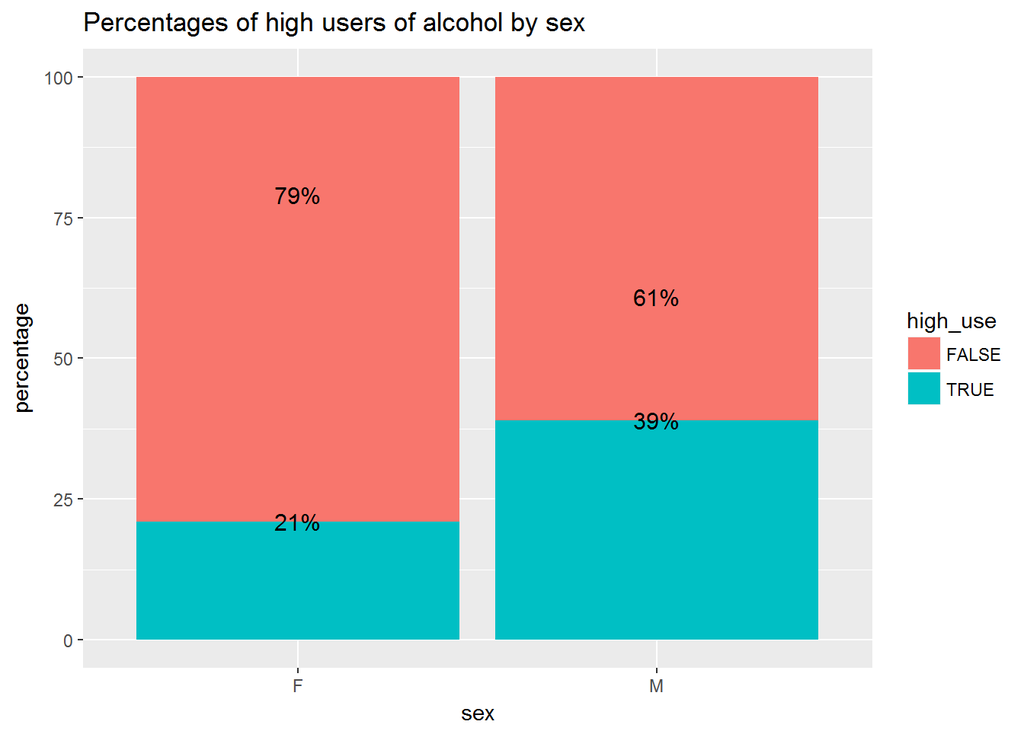

```r
alcodata_HighUseSex <- alcodata %>% group_by(sex, high_use) %>% summarise(count = n())
alcodata_sex <- alcodata %>% group_by(sex) %>% summarise(count=n())

alcodata_HighUseSex[1,3] <- round(alcodata_HighUseSex[1,3] / alcodata_sex[1,2] * 100, digits=0)
alcodata_HighUseSex[2,3] <- round(alcodata_HighUseSex[2,3] / alcodata_sex[1,2] * 100, digits=0)
alcodata_HighUseSex[3,3] <- round(alcodata_HighUseSex[3,3] / alcodata_sex[2,2] * 100, digits=0)
alcodata_HighUseSex[4,3] <- round(alcodata_HighUseSex[4,3] / alcodata_sex[2,2] * 100, digits=0)
colnames(alcodata_HighUseSex)[3] <- "percentage"

barchartSexHighuse <- ggplot() + geom_bar(aes(y = percentage, x = sex, fill = high_use), data = alcodata_HighUseSex,
                           stat="identity") +
  geom_text(data=alcodata_HighUseSex, aes(x = sex, y = percentage,
                                             label = paste0(percentage,"%")), size=4, position = position_dodge(width = 0.7)) +
  ggtitle("Percentages of high users of alcohol by sex")

barchartSexHighuse
```

### Logistic regression

First I create a model with glm function. I have only binary variables. Next chunk of code will provide us the summary of fitted model and odds ratios with the confidence intervals.

```r
modelAlco <- glm(high_use ~ activities + ageGroup + sex + MeduGroup, data = alcodata, family = "binomial")
modelAlco
```

```
##
## Call:  glm(formula = high_use ~ activities + ageGroup + sex + MeduGroup,
##     family = "binomial", data = alcodata)
##
## Coefficients:
##            (Intercept)           activitiesyes           ageGroup18-22
##                -1.0563                 -0.3693                  0.2309
##                   sexM  MeduGrouplow education
##                 0.8890                 -0.3568
##
## Degrees of Freedom: 381 Total (i.e. Null);  377 Residual
## Null Deviance:       465.7
## Residual Deviance: 445.5     AIC: 455.5
```

```r
summary(modelAlco)
```

```
##
## Call:
## glm(formula = high_use ~ activities + ageGroup + sex + MeduGroup,
##     family = "binomial", data = alcodata)
##
## Deviance Residuals:
##     Min       1Q   Median       3Q      Max
## -1.2045  -0.8524  -0.6600   1.2493   1.9687
##
## Coefficients:
##                        Estimate Std. Error z value Pr(>|z|)
## (Intercept)             -1.0563     0.2353  -4.488 7.17e-06 ***
## activitiesyes           -0.3693     0.2330  -1.585 0.113031
## ageGroup18-22            0.2309     0.2616   0.883 0.377365
## sexM                     0.8890     0.2346   3.790 0.000151 ***
## MeduGrouplow education  -0.3568     0.2403  -1.485 0.137568
## ---
## Signif. codes:  0 '***' 0.001 '**' 0.01 '*' 0.05 '.' 0.1 ' ' 1
##
## (Dispersion parameter for binomial family taken to be 1)
##
##     Null deviance: 465.68  on 381  degrees of freedom
## Residual deviance: 445.52  on 377  degrees of freedom
## AIC: 455.52
##
## Number of Fisher Scoring iterations: 4
```

```r
alcoOddRat <- coef(modelAlco) %>% exp
alcoConfInt <- confint(modelAlco) %>% exp
cbind(alcoOddRat, alcoConfInt)
```

```
##                        alcoOddRat     2.5 %    97.5 %
## (Intercept)             0.3477246 0.2166522 0.5462946
## activitiesyes           0.6912434 0.4364734 1.0897287
## ageGroup18-22           1.2597262 0.7490968 2.0939709
## sexM                    2.4326710 1.5431281 3.8763082
## MeduGrouplow education  0.6998840 0.4342537 1.1161097
```

In the previous chapter Regression and model validation is more about the theory of the regression model. As we saw earlier, the only variable that has statistically significant estimate in the model is sex. Eastimates of activities, age and mother’s educations have p-value greater than 0,05 so there is no enough evindence to reject null hypothesis. The same story is with the odds ratios. The first observation is that the confidence interval of the activities, age and mother’s education cointains 1,0. If the odds ratio is 1,0 then the probability is same for both groups: there same probability for both 15-17 and 18-22 to be high user. The confidence interval of the sex is from 1,5 to 3,9. If the odds ratio is 1,5 that means men are 1,5 more likely high users. With the odds ratio 3,9 it’s almost 4 times more probable. The confidence interval gives, in this case, the where the real odds ratio will be 95 times out of 100 cases.

The next step is to observe if my model can predict high consumption of alcohol.

```r
probabAlco <- predict(modelAlco, type = "response")
alcodata <- mutate(alcodata, probability = probabAlco)
alcodata <- mutate(alcodata, prediction = probabAlco > 0.5)
table(high_use = alcodata$high_use, prediction = probabAlco > 0.5)
```

```
##         prediction
## high_use FALSE TRUE
##    FALSE   261    7
##    TRUE    107    7
```

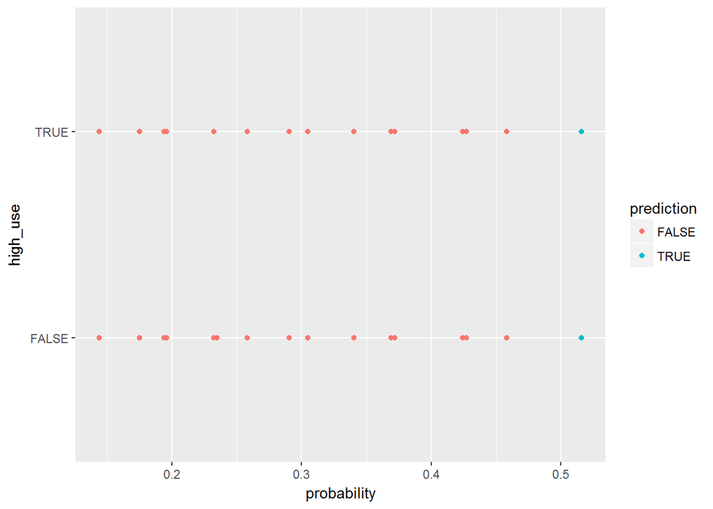

```r
scatPlot <- ggplot(alcodata, aes(x = probability, y = high_use, col = prediction)) + geom_point()
scatPlot
```

```r
table(high_use = alcodata$high_use, prediction = alcodata$prediction) %>% prop.table() %>% addmargins()
```

```
##         prediction
## high_use      FALSE       TRUE        Sum
##    FALSE 0.68324607 0.01832461 0.70157068
##    TRUE  0.28010471 0.01832461 0.29842932
##    Sum   0.96335079 0.03664921 1.00000000
```

It seems that my model can’t predict with high accuracy the results. Many cases that are true are predicted to be false. There is not much cases when false is predicted to be true, but not many true-true -combinatios either. In the scatter plot can be seen that there is quite low amount of TRUE predictions with probability of 0,5. Total training error can be calculated easily from the cross-tabulation by summing up TRUE-FALSE and FALSE-TRUE combinations or with the code below. The total training error is approximately 0,3 that is too much. It’s only slightly better than a simple guess with probabilities 0,5 and 0,5. I had to keep all four variables with me because without them the model would be even worse.

```r
loss_func <- function(class, prob) {
  n_wrong <- abs(class - prob) > 0.5
  mean(n_wrong)
}

loss_func(class = alcodata$high_use, prob = alcodata$probability)
```

```
## [1] 0.2984293
```

## Cross-validation

Next I will observe the cross-validation. With that I have better picture how my model predicts results.

```r
loss_func(class = alcodata$high_use, prob = alcodata$probability)
```

```
## [1] 0.2984293
```

```r
# K-fold cross-validation
cv <- cv.glm(data = alcodata, cost = loss_func, glmfit = modelAlco, K = 10)
cv$delta[1]
```

```
## [1] 0.3089005
```

It seems that the cross-validation with 10 fold gives slighlty bigger error, but the difference is negligible. My model is worse than in DataCamp. Next step was to add more variables. In first place I took 11 variables to the model. Then I calculated both training and testing errors and added them to the table. I reduced one explanatory variable each round.

```r
results
```

```
##     [,1]      [,2]      [,3]
##       11 0.2172775 0.2356021
## r10   10 0.2251309 0.2329843
## r9     9 0.2303665 0.2329843
## r8     8 0.2905759 0.3062827
## r7     7 0.2853403 0.2984293
## r6     6 0.2905759 0.2958115
## r5     5 0.2984293 0.3036649
## r4     4 0.2984293 0.3115183
## r3     3 0.2984293 0.2984293
## r2     2 0.2984293 0.2984293
## r1     1 0.2984293 0.2984293
```